# CS 422 Section-01 hw3

Rui Zou A20351034

## 2.1 K-means Clustering

### (a) Data cleanup

#### (i)

The “Name” attribute should be removed before clustering, because it is a nominal attribute, unique for each data object, thus no help for clustering.

#### (ii)

Yes. Standardization can help avoid letting an attribute with large values dominate the results of the calculation, it is usually necessary in data preprocessing.

#### (iii)

Clean the data to remove multiple spaces and make the comma character the delimiter.

```r
library(cluster)
library(ggplot2)
library(factoextra)
setwd("/Users/rzou/Academics/Courses/CS422 - Data Mining/homeworks/hw3")
set.seed(20)
mammals = read.csv("file19.txt", row.names = 1, sep="")
mammals
```

|  | I | i | C | c | P | p | M | m |
| --- | --- | --- | --- | --- | --- | --- | --- | --- |
| Opossum | 5 | 4 | 1 | 1 | 3 | 3 | 4 | 4 |
| Hairy tail mole | 3 | 3 | 1 | 1 | 4 | 4 | 3 | 3 |
| Common mole | 3 | 2 | 1 | 0 | 3 | 3 | 3 | 3 |
| Star nose mole | 3 | 3 | 1 | 1 | 4 | 4 | 3 | 3 |
| Brown bat | 2 | 3 | 1 | 1 | 3 | 3 | 3 | 3 |
| Silver hair bat | 2 | 3 | 1 | 1 | 2 | 3 | 3 | 3 |
| Pigmy bat | 2 | 3 | 1 | 1 | 2 | 2 | 3 | 3 |
| House bat | 2 | 3 | 1 | 1 | 1 | 2 | 3 | 3 |
| Red bat | 1 | 3 | 1 | 1 | 2 | 2 | 3 | 3 |
| Hoary bat | 1 | 3 | 1 | 1 | 2 | 2 | 3 | 3 |

[output cut: 56 more lines]

### (b) Clustering

#### (i)

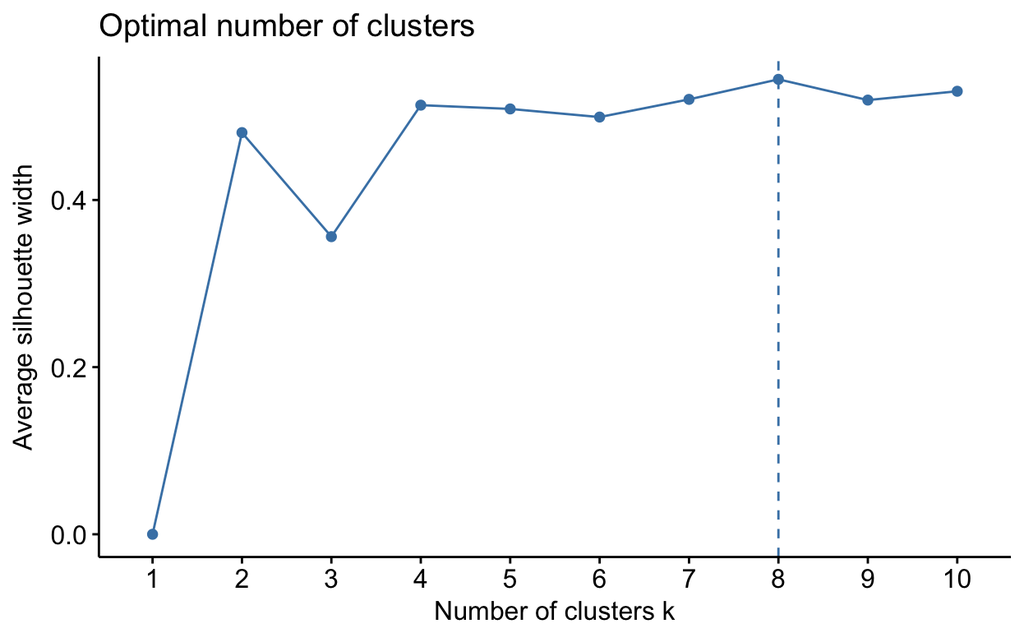

```r
# data standardization
mammals <- scale(mammals)
# determine optimal k
fviz_nbclust(mammals, kmeans, method = "silhouette")
```

So 8 clusters would be optimal.

#### (ii)

[figure not shown]

```r
# K-means clustering
k <- 8
km.res <- kmeans(mammals, k, nstart = 10)  # run 10 times of different initials and pick the best result
# Visualize kmeans clustering
fviz_cluster(km.res, mammals, repel = TRUE, ellipse.type = "norm")   # use repel = TRUE to avoid overplotting
```

#### (iii)

```r
km.res
```

```
K-means clustering with 8 clusters of sizes 9, 17, 9, 1, 15, 4, 8, 3

Cluster means:
            I          i          C          c          P           p          M
1  1.00371702  0.6310740  0.8257228  0.9059288  1.0915152  1.15723052  0.1819299
2 -0.67337977 -1.1881600 -1.1927107 -1.0871146 -1.2340884 -1.35769195  0.4678196
3 -1.51192817  1.3970672 -0.7441700 -1.0871146  0.3610716  0.45491131  0.4678196
4 -1.51192817 -2.0499024 -1.1927107 -1.0871146 -2.1041756 -1.91541603  4.7561664
5  1.00371702  0.4204258  0.8257228  0.9059288  0.5802046  0.40223737 -1.1903411
6  0.37480572 -0.9727244  0.8257228  0.9059288  0.9773834  1.04749314 -1.4619364
7 -0.04446848  0.5353248  0.8257228  0.9059288 -0.3579589  0.05985675  0.4678196
8  0.44468476 -0.9009125 -0.5198996 -1.0871146  0.0871552 -0.07182810  0.4678196
           m
1  0.2482230
2  0.3574411
3  0.3574411
4  5.2722560
5 -0.8876454
6 -1.8542256
7  0.3574411
8  0.3574411

Clustering vector:
        Opossum Hairy tail mole     Common mole  Star nose mole       Brown bat
              1               1               8               1               7
Silver hair bat       Pigmy bat       House bat         Red bat       Hoary bat
              7               7               7               7               7
  Lump nose bat       Armadillo            Pika Snowshoe rabbit          Beaver
              7               4               8               8               2
         Marmot       Groundhog     Prairie Dog Ground Squirrel        Chipmunk
              2               2               2               2               2
  Gray squirrel    Fox squirrel   Pocket gopher    Kangaroo rat        Pack rat
              2               2               2               2               2
    Field mouse         Muskrat       Black rat     House mouse       Porcupine
              2               2               2               2               2
     Guinea pig          Coyote            Wolf             Fox            Bear
              2               1               1               1               1
      Civet cat         Raccoon          Marten          Fisher          Weasel
              1               1               5               5               5
           Mink          Ferrer       Wolverine          Badger           Skunk
              5               5               5               5               5
    River otter       Sea otter          Jaguar          Ocelot          Cougar
              5               5               5               5               5
           Lynx        Fur seal        Sea lion          Walrus       Grey seal
              5               6               6               6               5
  Elephant seal         Peccary             Elk            Deer           Moose
              6               7               3               3               3
       Reindeer        Antelope           Bison   Mountain goat         Musk ox
              3               3               3               3               3
 Mountain sheep
              3

Within cluster sum of squares by cluster:
[1] 13.174224  9.591579  6.337449  0.000000 11.117050  6.226867  4.244696  4.546254
 (between_SS / total_SS =  89.4 %)

Available components:

[1] "cluster"      "centers"      "totss"        "withinss"     "tot.withinss"
[6] "betweenss"    "size"         "iter"         "ifault"
```

K-means clustering with 8 clusters of sizes 9, 17, 9, 1, 15, 4, 8, 3.

#### (iv)

```r
km.res$tot.withinss
```

```
[1] 55.23812
```

total SSE = 55.23812

#### (v)

```r
km.res$withinss
```

```
[1] 13.174224  9.591579  6.337449  0.000000 11.117050  6.226867  4.244696  4.546254
```

Within cluster sum of squares by cluster: 13.174224 9.591579 6.337449 0.000000 11.117050 6.226867 4.244696 4.546254

#### (vi)

```r
for (i in 1:8){
  print(paste("Cluster", i))
  animals = which(km.res$cluster==i)
  print(animals)
}
```

```
[1] "Cluster 1"
        Opossum Hairy tail mole  Star nose mole          Coyote            Wolf
              1               2               4              32              33
            Fox            Bear       Civet cat         Raccoon
             34              35              36              37
[1] "Cluster 2"
         Beaver          Marmot       Groundhog     Prairie Dog Ground Squirrel
             15              16              17              18              19
       Chipmunk   Gray squirrel    Fox squirrel   Pocket gopher    Kangaroo rat
             20              21              22              23              24
       Pack rat     Field mouse         Muskrat       Black rat     House mouse
             25              26              27              28              29
      Porcupine      Guinea pig
             30              31
[1] "Cluster 3"
           Elk           Deer          Moose       Reindeer       Antelope
            58             59             60             61             62
         Bison  Mountain goat        Musk ox Mountain sheep
            63             64             65             66
[1] "Cluster 4"
Armadillo
       12
[1] "Cluster 5"
     Marten      Fisher      Weasel        Mink      Ferrer   Wolverine
         38          39          40          41          42          43
     Badger       Skunk River otter   Sea otter      Jaguar      Ocelot
         44          45          46          47          48          49
     Cougar        Lynx   Grey seal
         50          51          55
[1] "Cluster 6"
     Fur seal      Sea lion        Walrus Elephant seal
           52            53            54            56
[1] "Cluster 7"
      Brown bat Silver hair bat       Pigmy bat       House bat         Red bat
              5               6               7               8               9
      Hoary bat   Lump nose bat         Peccary
             10              11              57
[1] "Cluster 8"
    Common mole            Pika Snowshoe rabbit
              3              13              14
```

Basically it basically makes sense.

## 2.2 Hierarchical clustering

```r
df = read.csv("file46.txt", row.names = 1, sep="")
df
```

|  | FI | SW | DA | NO | EN | GE | DU | FL | FR | IT | SP | PO |
| --- | --- | --- | --- | --- | --- | --- | --- | --- | --- | --- | --- | --- |
| West Germany | 0 | 0 | 0 | 0 | 21 | 100 | 2 | 1 | 10 | 2 | 1 | 0 |
| Italy | 0 | 0 | 0 | 0 | 5 | 3 | 0 | 0 | 11 | 100 | 1 | 0 |
| France | 0 | 2 | 3 | 0 | 10 | 7 | 1 | 1 | 100 | 12 | 7 | 1 |
| Netherlands | 0 | 0 | 0 | 0 | 41 | 47 | 100 | 100 | 16 | 2 | 2 | 0 |
| Belgium | 0 | 0 | 0 | 0 | 14 | 15 | 0 | 59 | 44 | 2 | 1 | 0 |
| Luxemburg | 0 | 0 | 0 | 0 | 31 | 100 | 4 | 1 | 92 | 10 | 0 | 0 |
| Great Britain | 0 | 0 | 0 | 0 | 100 | 7 | 0 | 0 | 15 | 3 | 2 | 0 |
| Portugal | 0 | 0 | 0 | 0 | 9 | 0 | 0 | 0 | 10 | 1 | 2 | 100 |
| Austria | 0 | 0 | 0 | 0 | 18 | 100 | 1 | 1 | 4 | 2 | 1 | 0 |
| Switzerland | 0 | 0 | 0 | 0 | 21 | 83 | 1 | 2 | 64 | 23 | 3 | 1 |

[output cut: 6 more lines]

### (a)

```r
singlelink <- eclust(df, "hclust", hc_method = "single")
```

```
Clustering k = 1,2,..., K.max (= 10): .. done
Bootstrapping, b = 1,2,..., B (= 100)  [one "." per sample]:
.................................................. 50
.................................................. 100
```

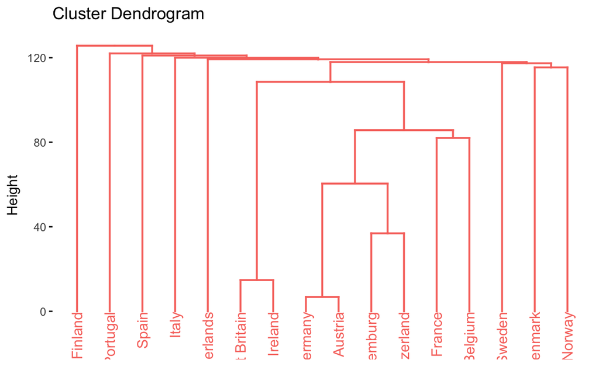

```r
fviz_dend(singlelink)
```

```r
completelink <- eclust(df, "hclust", hc_method = "complete")
```

```
Clustering k = 1,2,..., K.max (= 10): .. done
Bootstrapping, b = 1,2,..., B (= 100)  [one "." per sample]:
.................................................. 50
.................................................. 100
```

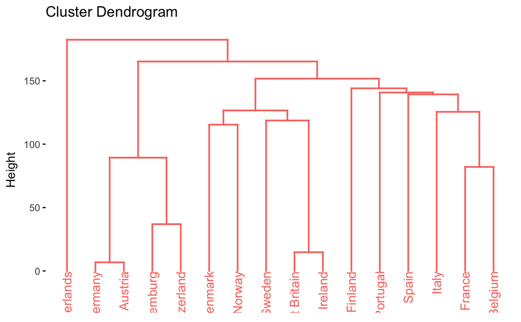

```r
fviz_dend(completelink)
```

```r
averagelink <- eclust(df, "hclust", hc_method = "average")
```

```
Clustering k = 1,2,..., K.max (= 10): .. done
Bootstrapping, b = 1,2,..., B (= 100)  [one "." per sample]:
.................................................. 50
.................................................. 100
```

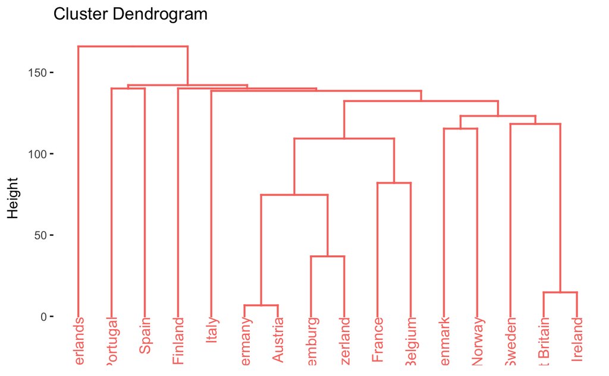

```r
fviz_dend(averagelink)
```

### (b)

For single link: {Great Britain, Ireland}, {West Germany, Austria}, {Luxemburg, Switzerland}, {France, Belgium}, {Denmark, Norway}

For complete link: {West Germany, Austria}, {Luxemburg, Switzerland}, {Denmark, Norway}, {Great Britain, Ireland}, {France, Belgium}

For average link: {Portugal, Spain}, {West Germany, Austria}, {Luxemburg, Switzerland}, {France, Belgium}, {Denmark, Norway}, {Great Britain, Ireland}

### (c)

Average link. Raw data show that Italian is not much frequently used in other countries than other popular languages, which indicates that it can be seen as a relative “outliers” to some extent. Because single link is sensitive to outliers and complete link is insensitive, average link then may be a better reflection of clustering.

### (d)

Average link. In (b) in average link strategy, there are 6 two-singleton clusters, more than those in other two strategies.

### (f)

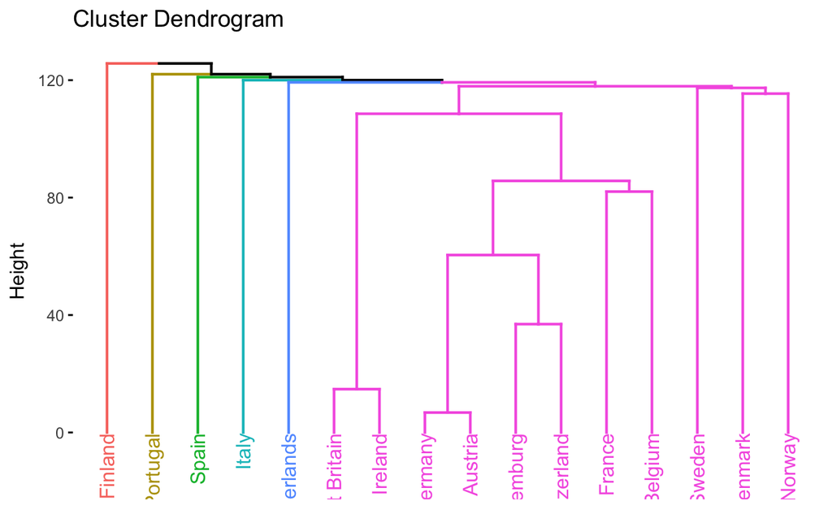

```r
singlelink2 <- eclust(df, "hclust", k=6, hc_method = "single")
fviz_dend(singlelink2)
```

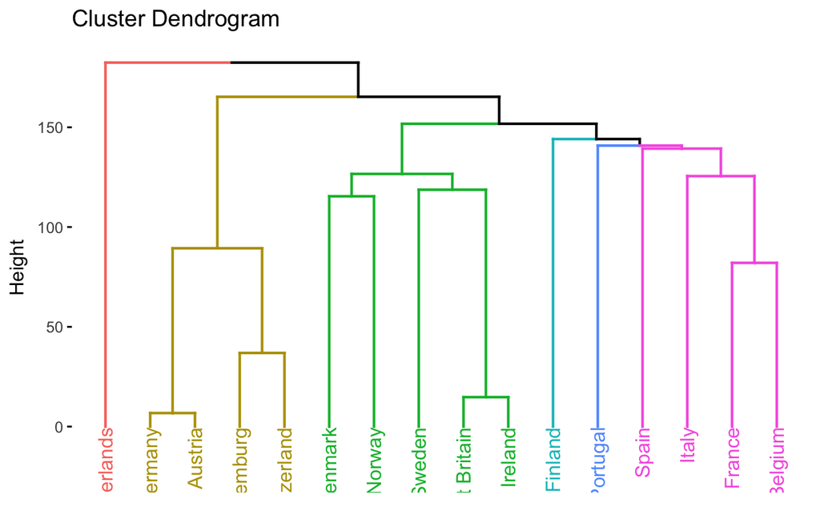

```r
completelink2 <- eclust(df, "hclust", k=6, hc_method = "complete")
fviz_dend(completelink2)
```

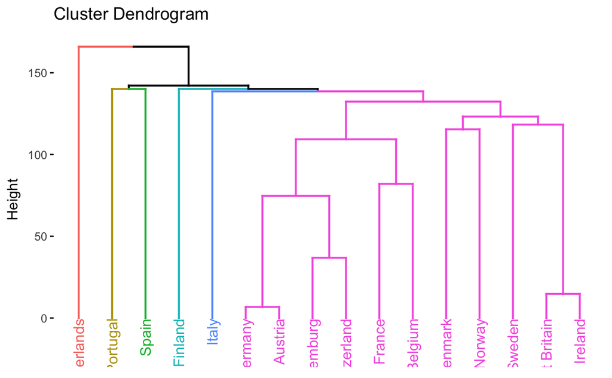

```r
averagelink2 <- eclust(df, "hclust", k=6, hc_method = "average")
fviz_dend(averagelink2)
```

### (g)

For single link:

```r
# Compute pairwise-distance matrices
dd <- dist(df, method ="euclidean")
# Statistics for singlelink clustering
single_stats <- fpc::cluster.stats(d=dd, clustering=singlelink2$cluster)
single_stats$clus.avg.silwidths
```

```
        1         2         3         4         5         6
0.1406125 0.0000000 0.0000000 0.0000000 0.0000000 0.0000000
```

```r
single_stats$dunn
```

```
[1] 0.7482147
```

For complete link:

```r
# Statistics for completelink clustering
complete_stats <- fpc::cluster.stats(d=dd, clustering=completelink2$cluster)
complete_stats$clus.avg.silwidths
```

```
         1          2          3          4          5          6
0.54209215 0.03554353 0.00000000 0.15949102 0.00000000 0.00000000
```

```r
complete_stats$dunn
```

```
[1] 0.6151269
```

For average link:

```r
# Statistics for averagelink clustering
average_stats <- fpc::cluster.stats(d=dd, clustering=averagelink2$cluster)
average_stats$clus.avg.silwidths
```

```
        1         2         3         4         5         6
0.1406125 0.0000000 0.0000000 0.0000000 0.0000000 0.0000000
```

```r
average_stats$dunn
```

```
[1] 0.7482147
```

### (i)

Based on Silhouette width, complete link is best.

## 2.3 K-Means and PCA

```r
htru = read.csv("HTRU_2-small.csv", sep=",")
head(htru)
```

|  | mean | std.dev | kurtosis | skewness | mean.dm.snr | std.dev.dm.snr | kurtosis.dm.snr | skewness.dm.snr | class |
| --- | --- | --- | --- | --- | --- | --- | --- | --- | --- |
| 1 | 45.60938 | 39.13683 | 3.646904656 | 13.7728696 | 127.943144 | 72.76457 | 0.06791464 | -0.826413 | 1 |
| 2 | 121.75781 | 44.74943 | 0.231819049 | 0.1846086 | 3.760870 | 22.86933 | 6.71857507 | 47.952567 | 0 |
| 3 | 112.97656 | 48.84741 | 0.272892611 | 0.2677589 | 94.927258 | 83.71522 | -0.21163662 | -1.861892 | 0 |
| 4 | 130.07031 | 51.38719 | -0.160128253 | -0.2094694 | 2.025084 | 13.17014 | 10.01610903 | 138.328787 | 0 |
| 5 | 111.11719 | 35.63500 | 0.237672636 | 1.6792307 | 3.688127 | 18.68339 | 6.66335683 | 54.090504 | 0 |
| 6 | 138.46094 | 52.77457 | -0.009090614 | -0.5518453 | 2.220736 | 13.20426 | 9.95369210 | 139.466872 | 0 |

### (a)

#### (i)

```r
htru.pca <- prcomp(htru[1:8], center = TRUE, scale. = TRUE)
summary(htru.pca)
```

```
Importance of components:
                          PC1    PC2    PC3     PC4     PC5     PC6     PC7
Standard deviation     2.0391 1.4581 0.8975 0.67426 0.51114 0.39844 0.14343
Proportion of Variance 0.5197 0.2657 0.1007 0.05683 0.03266 0.01984 0.00257
Cumulative Proportion  0.5197 0.7855 0.8862 0.94301 0.97566 0.99551 0.99808
                           PC8
Standard deviation     0.12396
Proportion of Variance 0.00192
Cumulative Proportion  1.00000
```

The cumulative variance by the first two components is 0.7855.

#### (ii)

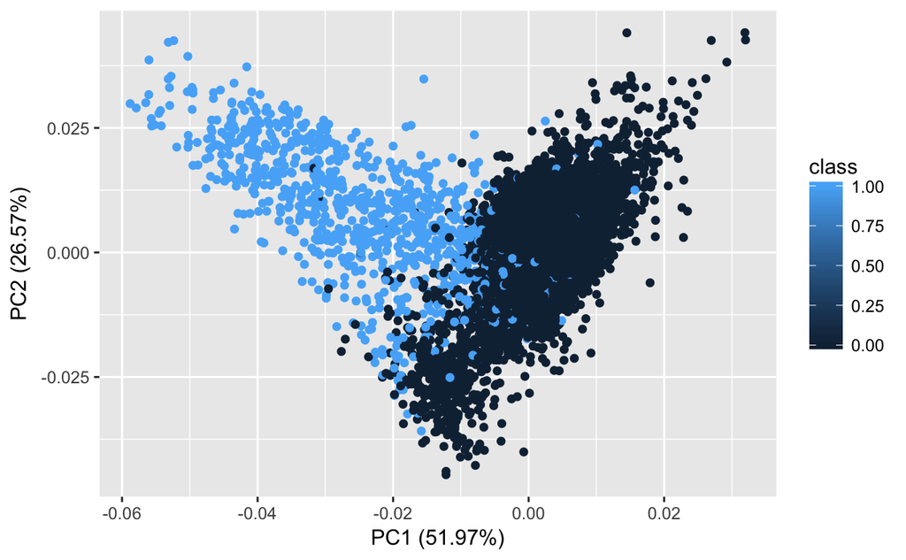

```r
library(ggfortify)
autoplot(htru.pca, data = htru, colour = 'class')
```

#### (iii)

We can see from the graph that the distribution of class 0 is much more than class 1, which is consistent with the original dataset.

### (b)

#### (i)

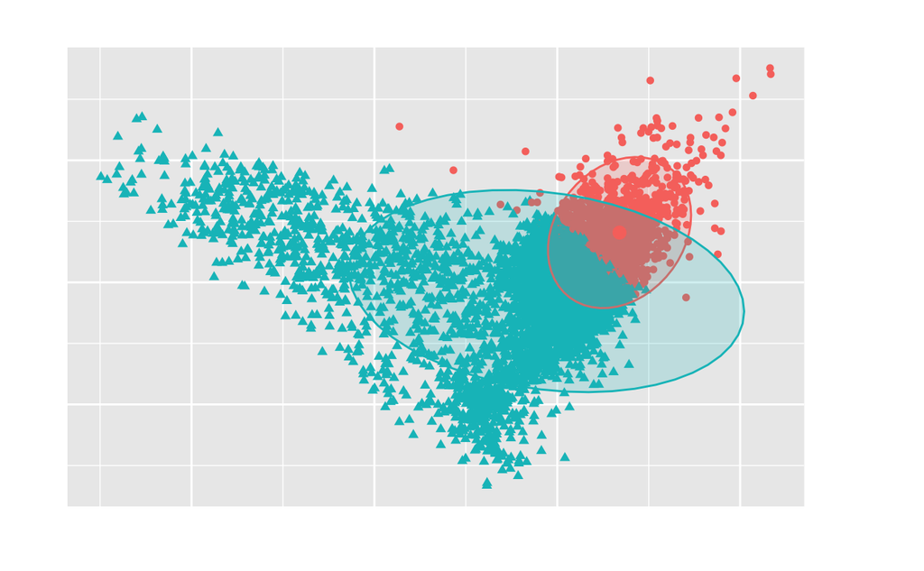

```r
htru.km <- kmeans(htru, 2)
fviz_cluster(htru.km, htru, repel = TRUE, ellipse.type = "norm")   # use repel = TRUE to avoid overplotting
```

#### (iii)

```r
htru.km
```

```
K-means clustering with 2 clusters of sizes 1486, 8514

Cluster means:
      mean  std.dev  kurtosis  skewness mean.dm.snr std.dev.dm.snr kurtosis.dm.snr
1 115.0278 46.70917 0.2360608 0.4603303    1.173571       11.63220         15.3191
2 110.1789 46.55915 0.5268934 2.0100011   14.324788       28.94661          7.0250
  skewness.dm.snr      class
1       292.13835 0.01009421
2        70.50056 0.11087620

Clustering vector:
   [1] 2 2 2 2 2 2 2 2 2 2 2 2 2 2 2 2 1 1 1 2 2 1 2 1 2 2 2 2 2 2 2 2 2 2 2 2 2 2
  [39] 2 2 2 2 2 2 2 2 2 2 2 1 1 2 2 2 2 2 2 2 1 2 1 2 2 2 2 2 2 2 2 2 2 2 2 1 2 2
  [77] 2 1 1 2 2 2 2 1 2 2 2 2 1 2 2 2 2 2 2 2 2 2 2 2 2 2 2 1 2 1 2 1 2 2 2 2 2 2
 [115] 2 2 1 2 2 2 2 2 2 1 2 1 2 2 2 2 2 2 2 2 2 2 2 2 2 2 2 2 2 2 2 2 2 2 2 2 2 2
```

[output cut: 33 more lines]

K-means clustering with 2 clusters of sizes 1486, 8514.

#### (iv)

```r
sum(htru$class == 0)
```

```
[1] 9041
```

```r
sum(htru$class == 1)
```

```
[1] 959
```

The distribution of the classes in the HTRU2 dataset is: 9041 for class 0, and 959 for class 1.

#### (vi)

```r
obs = which(htru.km$cluster == 2)
count <- 0
for (i in 1:length(obs)) {
  if (htru[obs[i], 9] == 0)
    count = count + 1
}
count
```

```
[1] 7570
```

```r
length(obs) - count
```

```
[1] 944
```

There are 7570 observations in this large cluster belong to class 0, and 944 observations belong to class 1.

#### (vii)

The larger cluster represents class 0.

#### (ix)

```r
dd <- dist(htru, method ="euclidean")
htru.km_stats <- fpc::cluster.stats(d=dd, clustering=htru.km$cluster)
htru.km_stats$clus.avg.silwidths
```

[output not shown]

#### (x)

The cluster which has larger Silhouette width is better.

### (c)

#### (i)

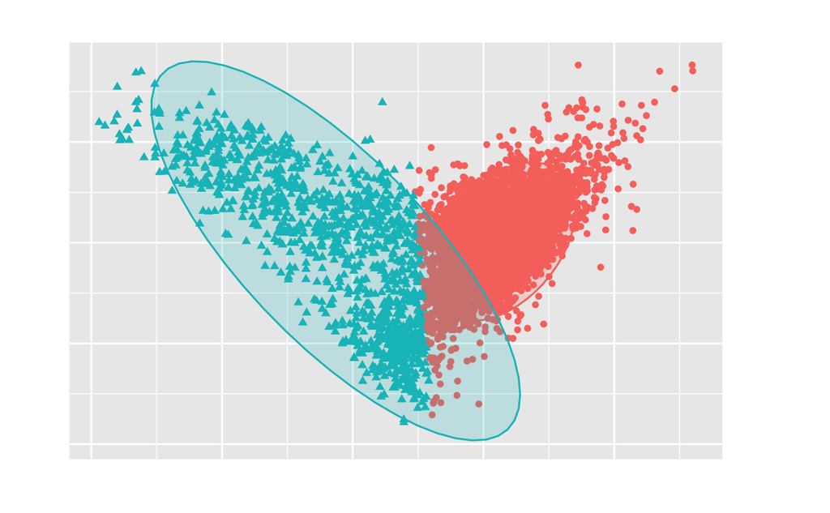

```r
pca.km <- kmeans(htru.pca$x[, 1:2], 2)
fviz_cluster(pca.km, htru.pca$x[, 1:2], repel = TRUE, ellipse.type = "norm")
```

#### (ii)

```r
pca.km
```

```
K-means clustering with 2 clusters of sizes 8851, 1149

Cluster means:
         PC1         PC2
1  0.5986306  0.03825117
2 -4.6113835 -0.29465717

Clustering vector:
   [1] 2 1 2 1 1 1 1 1 1 1 1 1 1 2 1 1 1 1 1 1 1 1 2 1 1 1 1 1 2 1 1 1 1 2 1 1 1 1
  [39] 1 1 1 1 1 1 1 1 1 1 1 1 1 1 1 1 1 1 1 1 1 1 1 1 2 1 1 1 2 1 1 1 2 2 1 1 2 2
  [77] 1 1 1 1 1 1 1 1 1 2 1 1 1 2 1 1 1 2 2 1 1 1 2 2 1 1 2 1 1 1 1 1 1 1 1 1 1 1
 [115] 1 1 1 1 1 2 1 2 1 1 1 1 1 2 1 1 1 1 1 1 1 1 2 2 1 2 1 1 1 1 1 2 1 1 1 1 1 1
 [153] 1 1 1 1 1 2 2 1 1 1 2 1 1 1 1 2 1 1 1 1 1 1 1 1 1 1 1 1 1 1 1 1 1 1 1 1 1 1
 [191] 1 1 1 1 1 1 1 1 1 1 1 1 2 1 2 1 1 1 1 1 1 2 1 1 1 1 1 2 1 1 1 1 1 1 1 1 1 1
 [229] 1 1 1 1 1 1 1 1 1 1 1 1 1 1 1 1 1 1 1 1 1 1 1 1 1 1 1 1 1 2 1 1 1 1 1 1 1 2
```

[output cut: 30 more lines]

```r
dd <- dist(htru, method ="euclidean")
pca.km_stats <- fpc::cluster.stats(d=dd, clustering=pca.km$cluster)
```

#### (iii)

The cluster which has larger Silhouette width is better.